# The Fragility Constellation: Rethinking Economic Vulnerability

Author

Carlos Wood

Published

April 27, 2025

# Introduction - The Paradox of Collapse

In 2020, Zambia’s central government debt-to-GDP ratio had reached a peak of 103.5%. While certainly concerning, countries like the UK carried higher levels of debt, but remained stable. The difference lay in the deeper structure of vulnerability.

Across the world, collapses often emerge not from an isolated weakness, but a combination of structural economic problems that result in financial fragility. Traditional diagnostics focused narrowly on debt or inflation often fail to capture these complex dynamics.

This project introduces the Fragility Constellation, a novel framework for mapping out economic vulnerability across several key dimensions simultaneously. Rather than asking ‘how much debt is too much’, the Fragility Constellation asks ‘across which dimensions is a country fragile, and how do these vulnerabilities evolve over time?’ This project aims to visualise and quantify these hidden structural risks.

# Why do Traditional Metrics Fall Short?

Traditional macroeconomic analysis typically relies heavily on headline indicators such as inflation, which, while useful signals, frequently fail to capture the true complexity of national economies. High public debt, for example, is seen as a universal warning sign for unstable economies. However, advanced economies, such as Japan and the UK, have maintained high debt levels for years, and remain some of the most stable globally. Conversely, countries with moderate debt burdens have experienced sudden and sharp collapse.

The core limitation of traditional diagnostics is that it tends to focus on single variables in isolation, and often fails to account for the multi-dimensional structure of economic fragility. As recent financial crises have shown, it is the structure of fragility, rather than any one metric alone, that better predicts an economy’s ability to withstand shocks. The Fragility Constellation aims to bridge this gap by using a multi-dimensional approach to classifying fragility.

# Building the Fragility Constellation

The Fragility Constellation was built by first gathering data on GDP Growth (annual %) and five indicators: Central government debt, total (% of GDP) Inflation, consumer prices (annual %) Total reserves in months of imports Current account balance (% of GDP) Foreign direct investment, net inflows (% of GDP) Data was also pulled from the UN Geoscheme to create custom regions due to inconsistencies in WorldBank aggregates.

The data was gathered using the WorldBank’s API and by reading the UN Geoscheme’s HTML format, before being cleaned to remove WorldBank aggregates. The data was then merged on common keys, ensuring that the data was ready for analysis.

Once the data was cleaned, and custom regions according to the UN Geoscheme were built, the data was prepared for a regression. First, Z-score normalisation was used to ensure that all data was comparable for the regression, ensuring comparable coefficients. Data was prepared so that a higher value always represented a worse outcome (e.g. FDI data was reversed, so a higher value represented a lower level of FDI).

Once the data was prepared, a regression was run of GDP growth for the next year of data on the five indicators to extract relative indicator importance for the Fragility Score based on historical data. The intention of this regression is not to predict GDP Growth perfectly. While the regression’s explanatory power was modest, its purpose was to inform the relative weight of each vulnerability indicator, rather than precise prediction. Using matrix multiplication, this was converted into a final fragility score, which was then normalised using min-max normalisation to get a final Fragility Score, with a value closer to zero indicating lower fragility, and a value closer to one indicating higher fragility.

# Zambia: A Fragility Case Study

At first glance, Zambia’s economy in the mid-2010s did not signal immediate alarm. Central government debt remained relatively stable, hovering around 50–60% of GDP — substantial, but not unusual by international standards. Many economies sustain higher ratios without incident. Yet deeper vulnerabilities beyond the headline figures told a very different story.

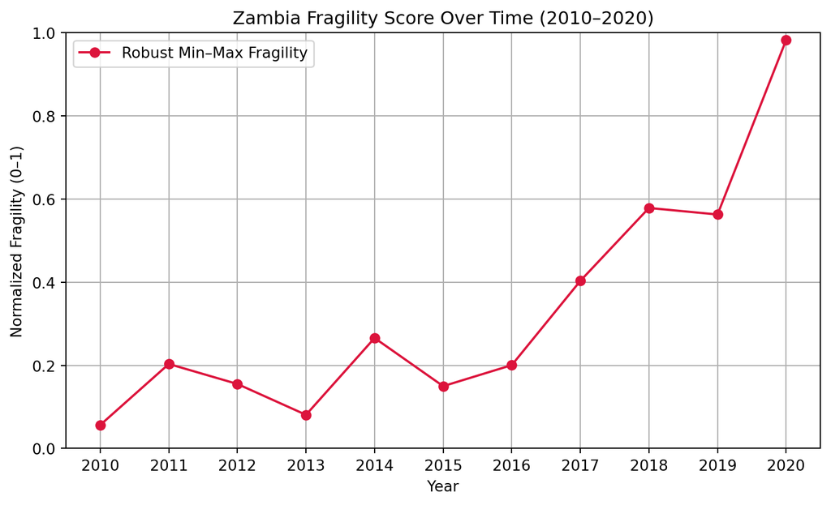

From 2015 onwards, Zambia’s economy weakened sharply across three critical dimensions: foreign direct investment collapsed, inflation accelerated, and foreign currency reserves steadily eroded. While conventional assessments continued to focus narrowly on debt — which, though rising, remained within a seemingly reasonable range — the Fragility Constellation captured the silent but systemic weakening underway.

Although fragility stabilised briefly between 2018 and 2019, this lull was short-lived. A rapid surge in debt, culminating in a 103.5% debt-to-GDP ratio by 2020, triggered the final collapse. But the underlying degradation had been building for years, long before debt levels could explain Zambia’s vulnerabilities.

Zambia’s fragility profile over time can be interactively explored later in the blog. By 2020, the year Zambia defaulted on its debt, the economy’s fragility was characterised by: - Extremely high inflation - Very low FDI - Low foreign reserves - High debt burden

[interactive chart not shown]

Zambia’s experience provides a compelling example for a multi-dimensional fragility analysis. Though the final collapse may have been caused by excessive debt, Zambia’s economy was primed to suffer from a shock when it came. But is Zambia an isolated case, or does a broader pattern of structural fragility exist across regions? To explore this, the Fragility Constellation framework was applied at the global level.

# Global Fragility Patterns

While Zambia offers a country-specific illustration, the Fragility Constellation framework also uncovers broader global patterns of vulnerability.

An animated bar chart illustrates average fragility scores across global regions between 2010 and 2021. The scores represent the mean structural fragility of countries within each region, based on the macroeconomic indicators selected.

[interactive chart not shown]

Although year-on-year fluctuations occur, fragility levels across regions remain persistently elevated, highlighting structural weaknesses that are resistant to short-term recovery cycles. Some regions, such as Eastern Asia, consistently exhibit higher fragility scores than the global average. While some regions show persistently higher fragility, broader regional trends remain less clearly defined, indicating that fragility reflects both regional vulnerabilities and distinct country-specific dynamics. Most regions show moderate to high fragility scores, reflecting the widespread nature of economic vulnerabilities globally.

While regional averages reveal some noteworthy variations, to fully understand how fragility evolves, a closer examination at the individual country level reveals how seemingly stable economies can quietly accumulate structural risks over time.

# Interactive Exploration

To allow for deeper exploration into individual country profiles, an interactive tool was built to explore changes in both the absolute level and structure of fragility over time. Users can select countries, and examine the different macroeconomic vulnerabilities affecting individual countries.

The interactive radar plot allows users to study the structure of fragility across different indicators for any country and year:

[interactive chart not shown]

Meanwhile, the interactive line plot shows the overall fragility trend over time, using two different normalisation methods, which can highlight different aspects of fragility:

- Standard min-max - Best for analysing a country’s overall fragility level, and for investigating outliers. Standard min-max is more sensitive to extreme cases.
- Robust min-max - Best for analysing trends within countries with less dramatic fragility profiles. Robust min-max focuses on more typical country experiences.

[interactive chart not shown]

You may wish to further explore Zambia’s fragility structure over the years, or any other country of interest. It is important to note that not all countries are available due to limitations in data availability from the WorldBank.

# Policy Implications

The findings of this project highlight that macroeconomic fragility is inherently multi-dimensional. Traditional headline metrics, such as public debt ratios, often don’t capture the whole image of an economy, and miss structural weaknesses that predispose economies to collapse.

The Fragility Constellation framework shows that it is not just the intensity of any one indicator, but the shape of vulnerabilities across multiple axes that determine systemic risk to an economy. Many developed countries may have higher debt-to-GDP ratios than less developed countries, for example, but do not suffer the same systematic risk. This highlights the need for multi-dimensional analysis to capture the full fragility of an economy.

This has critical implications for policymakers. Rather than focus on a single, headline indicator, they should focus their efforts on a country’s broader fragility constellation, monitoring to ensure that there is no accumulation of factors leading to structural fragility. Targeted interventions, such as stabilising inflation expectations or boosting reserves, can be designed more effectively when the full vulnerability structure is understood.

Moreover, though this is not a predictive model, it can act as a warning sign for hidden risk, as demonstrated in Zambia’s case. Fragility can accumulate quietly before external shocks trigger a visible collapse. As the model is developed to include more indicators, and to account for institutional strength, this can become a more predictive model, allowing for identification of a potential economic collapse.

By adopting a multi-dimensional fragility approach, policymakers can move towards proactive risk mitigation, strengthening economic resilience before vulnerabilities manifest via an external shock.

# Conclusion

The Fragility Constellation developed in this project provides a scalable, flexible framework for diagnosing macroeconomic vulnerability. While the current version focuses on key structural indicators such as debt, FDI, and inflation, the underlying code and methodology allow for easy expansion to include more indicators.

Future iterations of this project could also attempt to integrate additional dimensions of fragility, quantifying institutional strength and governance quality. The model could also allow for deeper analysis into less tangible factors, such as institutional trust and reputation. These factors explain why two economies with similar fragility profiles could exhibit very different resilience under shocks. With more indicators and a deeper dive into different factors affecting modern economies, which by nature are not easily quantified, this model could be scaled up from highlighting dangerous trends in a country’s structure to predicting economic stability. With additional indicators, care would be needed in ensuring that the dataset remains large enough for meaningful analysis.

Ultimately, this project demonstrates that fragility is not static or a single-dimensional concept. By blending indicators and finding fragility profiles, we can move towards earlier detection of systemic risks, and eventually, better prevention of economic crises. Paired with qualitative analysis, this can be a powerful tool for policymakers to shift priorities and policies to best protect economies from vulnerability.